# Optimal Treatment Analysis

## Outcome Variable

**Outcome Variable:** whz

## Predictor Variables

**Intervention Variable:** vagbrth

**Adjustment Set:**

- arm
- sex
- W_mage
- meducyrs
- feducyrs
- hhwealth_quart
- W_mhtcm
- W_mwtkg
- W_mbmi
- single
- W_nrooms
- brthmon
- W_parity
- impfloor
- delta_W_mage
- delta_meducyrs
- delta_feducyrs
- delta_hhwealth_quart
- delta_W_mhtcm
- delta_W_mwtkg
- delta_W_mbmi
- delta_single
- delta_W_nrooms
- delta_brthmon
- delta_W_parity
- delta_impfloor

## Stratifying Variables

The analysis was stratified on these variable(s):

- agecat
- studyid
- country

## Data Summary

| agecat | studyid | country | vagbrth | n_cell | n |
| --- | --- | --- | --- | --- | --- |
| Birth | ki1000108-CMC-V-BCS-2002 | INDIA | 0 | 10 | 86 |
| Birth | ki1000108-CMC-V-BCS-2002 | INDIA | 1 | 76 | 86 |
| Birth | ki1000108-IRC | INDIA | 0 | 66 | 343 |
| Birth | ki1000108-IRC | INDIA | 1 | 277 | 343 |
| Birth | ki1017093b-PROVIDE | BANGLADESH | 0 | 108 | 532 |
| Birth | ki1017093b-PROVIDE | BANGLADESH | 1 | 424 | 532 |
| Birth | ki1017093c-NIH-Crypto | BANGLADESH | 0 | 184 | 465 |
| Birth | ki1017093c-NIH-Crypto | BANGLADESH | 1 | 281 | 465 |
| Birth | ki1119695-PROBIT | BELARUS | 0 | 1593 | 13830 |
| Birth | ki1119695-PROBIT | BELARUS | 1 | 12237 | 13830 |
| Birth | ki1126311-ZVITAMBO | ZIMBABWE | 0 | 1100 | 12814 |
| Birth | ki1126311-ZVITAMBO | ZIMBABWE | 1 | 11714 | 12814 |
| Birth | kiGH5241-JiVitA-3 | BANGLADESH | 0 | 1409 | 22026 |
| Birth | kiGH5241-JiVitA-3 | BANGLADESH | 1 | 20617 | 22026 |
| Birth | kiGH5241-JiVitA-4 | BANGLADESH | 0 | 71 | 2395 |
| Birth | kiGH5241-JiVitA-4 | BANGLADESH | 1 | 2324 | 2395 |
| 6 months | ki1000108-CMC-V-BCS-2002 | INDIA | 0 | 25 | 368 |
| 6 months | ki1000108-CMC-V-BCS-2002 | INDIA | 1 | 343 | 368 |
| 6 months | ki1000108-IRC | INDIA | 0 | 68 | 408 |
| 6 months | ki1000108-IRC | INDIA | 1 | 340 | 408 |
| 6 months | ki1017093b-PROVIDE | BANGLADESH | 0 | 139 | 603 |
| 6 months | ki1017093b-PROVIDE | BANGLADESH | 1 | 464 | 603 |
| 6 months | ki1017093c-NIH-Crypto | BANGLADESH | 0 | 187 | 457 |
| 6 months | ki1017093c-NIH-Crypto | BANGLADESH | 1 | 270 | 457 |
| 6 months | ki1066203-TanzaniaChild2 | TANZANIA, UNITED REPUBLIC OF | 0 | 189 | 2004 |
| 6 months | ki1066203-TanzaniaChild2 | TANZANIA, UNITED REPUBLIC OF | 1 | 1815 | 2004 |
| 6 months | ki1119695-PROBIT | BELARUS | 0 | 1798 | 15758 |
| 6 months | ki1119695-PROBIT | BELARUS | 1 | 13960 | 15758 |
| 6 months | ki1126311-ZVITAMBO | ZIMBABWE | 0 | 721 | 8437 |
| 6 months | ki1126311-ZVITAMBO | ZIMBABWE | 1 | 7716 | 8437 |
| 6 months | kiGH5241-JiVitA-3 | BANGLADESH | 0 | 1069 | 16648 |
| 6 months | kiGH5241-JiVitA-3 | BANGLADESH | 1 | 15579 | 16648 |
| 6 months | kiGH5241-JiVitA-4 | BANGLADESH | 0 | 337 | 4056 |
| 6 months | kiGH5241-JiVitA-4 | BANGLADESH | 1 | 3719 | 4056 |
| 24 months | ki1000108-CMC-V-BCS-2002 | INDIA | 0 | 25 | 372 |
| 24 months | ki1000108-CMC-V-BCS-2002 | INDIA | 1 | 347 | 372 |
| 24 months | ki1000108-IRC | INDIA | 0 | 69 | 409 |
| 24 months | ki1000108-IRC | INDIA | 1 | 340 | 409 |
| 24 months | ki1017093b-PROVIDE | BANGLADESH | 0 | 137 | 579 |
| 24 months | ki1017093b-PROVIDE | BANGLADESH | 1 | 442 | 579 |
| 24 months | ki1017093c-NIH-Crypto | BANGLADESH | 0 | 99 | 260 |
| 24 months | ki1017093c-NIH-Crypto | BANGLADESH | 1 | 161 | 260 |
| 24 months | ki1066203-TanzaniaChild2 | TANZANIA, UNITED REPUBLIC OF | 0 | 2 | 6 |
| 24 months | ki1066203-TanzaniaChild2 | TANZANIA, UNITED REPUBLIC OF | 1 | 4 | 6 |
| 24 months | ki1119695-PROBIT | BELARUS | 0 | 463 | 3972 |
| 24 months | ki1119695-PROBIT | BELARUS | 1 | 3509 | 3972 |
| 24 months | ki1126311-ZVITAMBO | ZIMBABWE | 0 | 28 | 426 |
| 24 months | ki1126311-ZVITAMBO | ZIMBABWE | 1 | 398 | 426 |
| 24 months | kiGH5241-JiVitA-3 | BANGLADESH | 0 | 471 | 8490 |
| 24 months | kiGH5241-JiVitA-3 | BANGLADESH | 1 | 8019 | 8490 |
| 24 months | kiGH5241-JiVitA-4 | BANGLADESH | 0 | 323 | 4008 |
| 24 months | kiGH5241-JiVitA-4 | BANGLADESH | 1 | 3685 | 4008 |

The following strata were considered:

- agecat: 24 months, studyid: ki1000108-CMC-V-BCS-2002, country: INDIA
- agecat: 24 months, studyid: ki1000108-IRC, country: INDIA
- agecat: 24 months, studyid: ki1017093b-PROVIDE, country: BANGLADESH
- agecat: 24 months, studyid: ki1017093c-NIH-Crypto, country: BANGLADESH
- agecat: 24 months, studyid: ki1066203-TanzaniaChild2, country: TANZANIA, UNITED REPUBLIC OF
- agecat: 24 months, studyid: ki1119695-PROBIT, country: BELARUS
- agecat: 24 months, studyid: ki1126311-ZVITAMBO, country: ZIMBABWE
- agecat: 24 months, studyid: kiGH5241-JiVitA-3, country: BANGLADESH
- agecat: 24 months, studyid: kiGH5241-JiVitA-4, country: BANGLADESH
- agecat: 6 months, studyid: ki1000108-CMC-V-BCS-2002, country: INDIA
- agecat: 6 months, studyid: ki1000108-IRC, country: INDIA
- agecat: 6 months, studyid: ki1017093b-PROVIDE, country: BANGLADESH
- agecat: 6 months, studyid: ki1017093c-NIH-Crypto, country: BANGLADESH
- agecat: 6 months, studyid: ki1066203-TanzaniaChild2, country: TANZANIA, UNITED REPUBLIC OF
- agecat: 6 months, studyid: ki1119695-PROBIT, country: BELARUS
- agecat: 6 months, studyid: ki1126311-ZVITAMBO, country: ZIMBABWE
- agecat: 6 months, studyid: kiGH5241-JiVitA-3, country: BANGLADESH
- agecat: 6 months, studyid: kiGH5241-JiVitA-4, country: BANGLADESH
- agecat: Birth, studyid: ki1000108-CMC-V-BCS-2002, country: INDIA
- agecat: Birth, studyid: ki1000108-IRC, country: INDIA
- agecat: Birth, studyid: ki1017093b-PROVIDE, country: BANGLADESH
- agecat: Birth, studyid: ki1017093c-NIH-Crypto, country: BANGLADESH
- agecat: Birth, studyid: ki1119695-PROBIT, country: BELARUS
- agecat: Birth, studyid: ki1126311-ZVITAMBO, country: ZIMBABWE
- agecat: Birth, studyid: kiGH5241-JiVitA-3, country: BANGLADESH
- agecat: Birth, studyid: kiGH5241-JiVitA-4, country: BANGLADESH

### Dropped Strata

Some strata were dropped due to rare outcomes:

- agecat: 24 months, studyid: ki1066203-TanzaniaChild2, country: TANZANIA, UNITED REPUBLIC OF

## Methods Detail

We’re interested in the causal parameters $E[Y_a]$ for all values of $a \in \mathcal{A}$. These parameters represent the mean outcome if, possibly contrary to fact, we intervened to set all units to have $A=a$. Under the randomization and positivity assumptions, these are identified by the statistical parameters $\psi_a=E_W[E_{Y|A,W}(Y|A=a,W)]$. In addition, we’re interested in the mean of $Y$, $E[Y]$ under no intervention (the observed mean). We will estimate these parameters by using SuperLearner to fit the relevant likelihood factors – $E_{Y|A,W}(Y|A=a,W)$ and $p(A=a|W)$, and then updating our likelihood fit using a joint TMLE.

For unadjusted analyses ($W=\{\}$), initial likelihoods were estimated using Lrnr_glm to estimate the simple $E(Y|A)$ and Lrnr_mean to estimate $p(A)$. For adjusted analyses, a small library containing Lrnr_glmnet, Lrnr_xgboost, and Lrnr_mean was used.

# Results Detail

## Results Plots

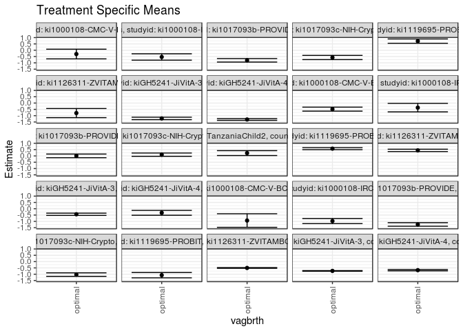

## Results Table

### Parameter: TSM

| agecat | studyid | country | intervention_level | baseline_level | estimate | ci_lower | ci_upper |
| --- | --- | --- | --- | --- | --- | --- | --- |
| Birth | ki1000108-CMC-V-BCS-2002 | INDIA | optimal | observed | -0.9345699 | -1.4722327 | -0.3969072 |
| Birth | ki1000108-IRC | INDIA | optimal | observed | -0.9742609 | -1.1755268 | -0.7729950 |
| Birth | ki1017093b-PROVIDE | BANGLADESH | optimal | observed | -1.2439021 | -1.3832157 | -1.1045886 |
| Birth | ki1017093c-NIH-Crypto | BANGLADESH | optimal | observed | -1.0292240 | -1.1675673 | -0.8908807 |
| Birth | ki1119695-PROBIT | BELARUS | optimal | observed | -1.0759049 | -1.2854556 | -0.8663541 |
| Birth | ki1126311-ZVITAMBO | ZIMBABWE | optimal | observed | -0.5037925 | -0.5309396 | -0.4766453 |
| Birth | kiGH5241-JiVitA-3 | BANGLADESH | optimal | observed | -0.7377867 | -0.7607451 | -0.7148283 |
| Birth | kiGH5241-JiVitA-4 | BANGLADESH | optimal | observed | -0.6781737 | -0.7316021 | -0.6247452 |
| 6 months | ki1000108-CMC-V-BCS-2002 | INDIA | optimal | observed | -0.4800071 | -0.6376163 | -0.3223978 |
| 6 months | ki1000108-IRC | INDIA | optimal | observed | -0.3629888 | -0.7004898 | -0.0254879 |
| 6 months | ki1017093b-PROVIDE | BANGLADESH | optimal | observed | 0.0012210 | -0.1438311 | 0.1462730 |
| 6 months | ki1017093c-NIH-Crypto | BANGLADESH | optimal | observed | 0.0981305 | -0.0324058 | 0.2286667 |
| 6 months | ki1066203-TanzaniaChild2 | TANZANIA, UNITED REPUBLIC OF | optimal | observed | 0.2229166 | 0.0300040 | 0.4158291 |
| 6 months | ki1119695-PROBIT | BELARUS | optimal | observed | 0.5743259 | 0.4948672 | 0.6537845 |
| 6 months | ki1126311-ZVITAMBO | ZIMBABWE | optimal | observed | 0.4379681 | 0.3449841 | 0.5309522 |
| 6 months | kiGH5241-JiVitA-3 | BANGLADESH | optimal | observed | -0.4374289 | -0.5271919 | -0.3476658 |
| 6 months | kiGH5241-JiVitA-4 | BANGLADESH | optimal | observed | -0.3221688 | -0.5139037 | -0.1304339 |
| 24 months | ki1000108-CMC-V-BCS-2002 | INDIA | optimal | observed | -0.3027659 | -0.6862893 | 0.0807575 |
| 24 months | ki1000108-IRC | INDIA | optimal | observed | -0.5353041 | -0.7874324 | -0.2831759 |
| 24 months | ki1017093b-PROVIDE | BANGLADESH | optimal | observed | -0.7995827 | -0.9388998 | -0.6602657 |
| 24 months | ki1017093c-NIH-Crypto | BANGLADESH | optimal | observed | -0.5750690 | -0.7418665 | -0.4082714 |
| 24 months | ki1119695-PROBIT | BELARUS | optimal | observed | 0.7209630 | 0.5487746 | 0.8931515 |
| 24 months | ki1126311-ZVITAMBO | ZIMBABWE | optimal | observed | -0.7936652 | -1.1556076 | -0.4317228 |
| 24 months | kiGH5241-JiVitA-3 | BANGLADESH | optimal | observed | -1.2181274 | -1.3153510 | -1.1209038 |
| 24 months | kiGH5241-JiVitA-4 | BANGLADESH | optimal | observed | -1.3005807 | -1.3706302 | -1.2305311 |

### Parameter: E(Y)

| agecat | studyid | country | intervention_level | baseline_level | estimate | ci_lower | ci_upper |
| --- | --- | --- | --- | --- | --- | --- | --- |
| Birth | ki1000108-CMC-V-BCS-2002 | INDIA | observed | observed | -0.4648256 | -0.7643210 | -0.1653302 |
| Birth | ki1000108-IRC | INDIA | observed | observed | -1.0105831 | -1.1973019 | -0.8238643 |
| Birth | ki1017093b-PROVIDE | BANGLADESH | observed | observed | -1.2984586 | -1.3752758 | -1.2216415 |
| Birth | ki1017093c-NIH-Crypto | BANGLADESH | observed | observed | -1.1549785 | -1.2577390 | -1.0522180 |
| Birth | ki1119695-PROBIT | BELARUS | observed | observed | -1.1448633 | -1.3544229 | -0.9353037 |
| Birth | ki1126311-ZVITAMBO | ZIMBABWE | observed | observed | -0.5168886 | -0.5428625 | -0.4909146 |
| Birth | kiGH5241-JiVitA-3 | BANGLADESH | observed | observed | -0.7497893 | -0.7676477 | -0.7319310 |
| Birth | kiGH5241-JiVitA-4 | BANGLADESH | observed | observed | -0.6890188 | -0.7414800 | -0.6365575 |
| 6 months | ki1000108-CMC-V-BCS-2002 | INDIA | observed | observed | -0.5026766 | -0.6536848 | -0.3516685 |
| 6 months | ki1000108-IRC | INDIA | observed | observed | -0.5989297 | -0.7344491 | -0.4634104 |
| 6 months | ki1017093b-PROVIDE | BANGLADESH | observed | observed | -0.1990907 | -0.2817968 | -0.1163845 |
| 6 months | ki1017093c-NIH-Crypto | BANGLADESH | observed | observed | 0.0515536 | -0.0469240 | 0.1500313 |
| 6 months | ki1066203-TanzaniaChild2 | TANZANIA, UNITED REPUBLIC OF | observed | observed | 0.0769382 | 0.0241090 | 0.1297674 |
| 6 months | ki1119695-PROBIT | BELARUS | observed | observed | 0.5792439 | 0.5193388 | 0.6391490 |
| 6 months | ki1126311-ZVITAMBO | ZIMBABWE | observed | observed | 0.3116179 | 0.2858347 | 0.3374010 |
| 6 months | kiGH5241-JiVitA-3 | BANGLADESH | observed | observed | -0.5930619 | -0.6126597 | -0.5734642 |
| 6 months | kiGH5241-JiVitA-4 | BANGLADESH | observed | observed | -0.3758037 | -0.4184544 | -0.3331531 |
| 24 months | ki1000108-CMC-V-BCS-2002 | INDIA | observed | observed | -0.5571505 | -0.6585247 | -0.4557763 |
| 24 months | ki1000108-IRC | INDIA | observed | observed | -0.7458150 | -0.8368180 | -0.6548120 |
| 24 months | ki1017093b-PROVIDE | BANGLADESH | observed | observed | -0.8928670 | -0.9755153 | -0.8102187 |
| 24 months | ki1017093c-NIH-Crypto | BANGLADESH | observed | observed | -0.8343077 | -0.9482310 | -0.7203844 |
| 24 months | ki1119695-PROBIT | BELARUS | observed | observed | 0.6874295 | 0.5756922 | 0.7991668 |
| 24 months | ki1126311-ZVITAMBO | ZIMBABWE | observed | observed | -1.1864319 | -1.2865891 | -1.0862748 |
| 24 months | kiGH5241-JiVitA-3 | BANGLADESH | observed | observed | -1.3000247 | -1.3234004 | -1.2766491 |
| 24 months | kiGH5241-JiVitA-4 | BANGLADESH | observed | observed | -1.2433658 | -1.2774681 | -1.2092634 |

### Parameter: PAR

| agecat | studyid | country | intervention_level | baseline_level | estimate | ci_lower | ci_upper |
| --- | --- | --- | --- | --- | --- | --- | --- |
| Birth | ki1000108-CMC-V-BCS-2002 | INDIA | optimal | observed | 0.4697444 | -0.0677351 | 1.0072238 |
| Birth | ki1000108-IRC | INDIA | optimal | observed | -0.0363222 | -0.1373922 | 0.0647478 |
| Birth | ki1017093b-PROVIDE | BANGLADESH | optimal | observed | -0.0545565 | -0.1722286 | 0.0631156 |
| Birth | ki1017093c-NIH-Crypto | BANGLADESH | optimal | observed | -0.1257545 | -0.2390390 | -0.0124700 |
| Birth | ki1119695-PROBIT | BELARUS | optimal | observed | -0.0689585 | -0.1581700 | 0.0202531 |
| Birth | ki1126311-ZVITAMBO | ZIMBABWE | optimal | observed | -0.0130961 | -0.0211637 | -0.0050285 |
| Birth | kiGH5241-JiVitA-3 | BANGLADESH | optimal | observed | -0.0120026 | -0.0267472 | 0.0027420 |
| Birth | kiGH5241-JiVitA-4 | BANGLADESH | optimal | observed | -0.0108451 | -0.0212723 | -0.0004179 |
| 6 months | ki1000108-CMC-V-BCS-2002 | INDIA | optimal | observed | -0.0226696 | -0.0579467 | 0.0126075 |
| 6 months | ki1000108-IRC | INDIA | optimal | observed | -0.2359409 | -0.5462633 | 0.0743814 |
| 6 months | ki1017093b-PROVIDE | BANGLADESH | optimal | observed | -0.2003116 | -0.3324715 | -0.0681517 |
| 6 months | ki1017093c-NIH-Crypto | BANGLADESH | optimal | observed | -0.0465768 | -0.1454345 | 0.0522808 |
| 6 months | ki1066203-TanzaniaChild2 | TANZANIA, UNITED REPUBLIC OF | optimal | observed | -0.1459783 | -0.3297643 | 0.0378076 |
| 6 months | ki1119695-PROBIT | BELARUS | optimal | observed | 0.0049180 | -0.0316062 | 0.0414422 |
| 6 months | ki1126311-ZVITAMBO | ZIMBABWE | optimal | observed | -0.1263502 | -0.2154336 | -0.0372669 |
| 6 months | kiGH5241-JiVitA-3 | BANGLADESH | optimal | observed | -0.1556331 | -0.2422310 | -0.0690351 |
| 6 months | kiGH5241-JiVitA-4 | BANGLADESH | optimal | observed | -0.0536350 | -0.2391707 | 0.1319008 |
| 24 months | ki1000108-CMC-V-BCS-2002 | INDIA | optimal | observed | -0.2543846 | -0.6230675 | 0.1142983 |
| 24 months | ki1000108-IRC | INDIA | optimal | observed | -0.2105109 | -0.4350123 | 0.0139905 |
| 24 months | ki1017093b-PROVIDE | BANGLADESH | optimal | observed | -0.0932843 | -0.2197552 | 0.0331867 |
| 24 months | ki1017093c-NIH-Crypto | BANGLADESH | optimal | observed | -0.2592387 | -0.3907451 | -0.1277323 |
| 24 months | ki1119695-PROBIT | BELARUS | optimal | observed | -0.0335335 | -0.1436751 | 0.0766081 |
| 24 months | ki1126311-ZVITAMBO | ZIMBABWE | optimal | observed | -0.3927668 | -0.7460568 | -0.0394767 |
| 24 months | kiGH5241-JiVitA-3 | BANGLADESH | optimal | observed | -0.0818973 | -0.1776665 | 0.0138718 |
| 24 months | kiGH5241-JiVitA-4 | BANGLADESH | optimal | observed | 0.0572149 | -0.0040302 | 0.1184599 |